# The Barca Foundation’s Future Megaproject: Diving into Africa’s Disastrous Nuances and Promising Football Development

Project 2  
AUTHOR: SID 541015192

# Client Bio and Recommendation

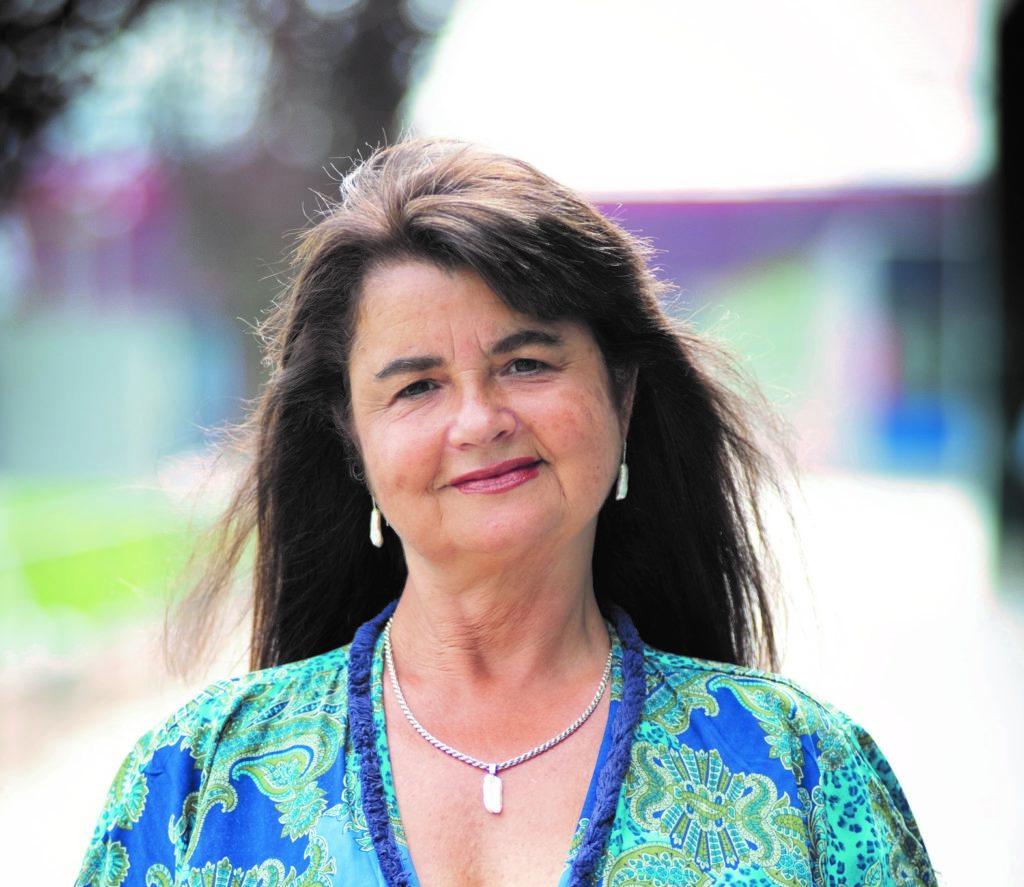

**Mrs. Marta Segú -** *Director of the Barça Foundation*

– [*LinkedIn*](https://www.linkedin.com/in/marta-segu-estruch-8b94a427/?originalSubdomain=es) *| [Website](https://foundation.fcbarcelona.com/en/)* –

The Barça Foundation is the charitable arm of Barcelona Football Club in Spain. They support struggling youths through sports, education, and health while identifying future football talents.

One of Mrs. Segú’s duties is to suggest geographical areas of action. Her goal is to pinpoint an area under crisis for maximizing both social good activities and talent intake chances.

**Recommendation**:

Millions of Africans are affected by natural disasters every year. Data analysis and previous research suggest this crisis **positively** correlates with **rising emigration rates**. This trend, alongside **the ever-increasing impact of young African footballers** in Europe’s top leagues, presents an opportunity for Mrs. Segú to achieve both her goals: aid the youth and scout football prodigies. Therefore, **concentrating disaster relief efforts** **in Africa, particularly near the Horn of Africa,** aligns with the Barça Foundation’s vision.

# Evidence

The analysis focuses on three variables:

- **People affected by natural disasters per million** from the Natural Disaster data.
- **UNHCR Refugees by country of origin per 300,000** from Gapminder’s UNHCR Refugee data.
- **Under-22 Non-European Footballers in Europe’s Big Five Leagues** from FBref

```r
# Loading the necessary libraries
library(tidyverse)
library(plotly)
library(gganimate)
library(sf)
library(rnaturalearth)
library(rnaturalearthdata)
library(waffle)

# Reading the datasets
Af_all = read.csv("G:/YEAR 1/SEMESTER 1/DATA1001/Coding Stuff/Project 2/Exported Databases/merged_af_exp.csv")
Af_c = read.csv("G:/YEAR 1/SEMESTER 1/DATA1001/Coding Stuff/Project 2/Exported Databases/af_c.csv")
y_fb_noneu = read.csv("G:/YEAR 1/SEMESTER 1/DATA1001/Coding Stuff/Project 2/Exported Databases/continent_counts_df.csv")
```

## I. A “Disastrous” Upwards Trend

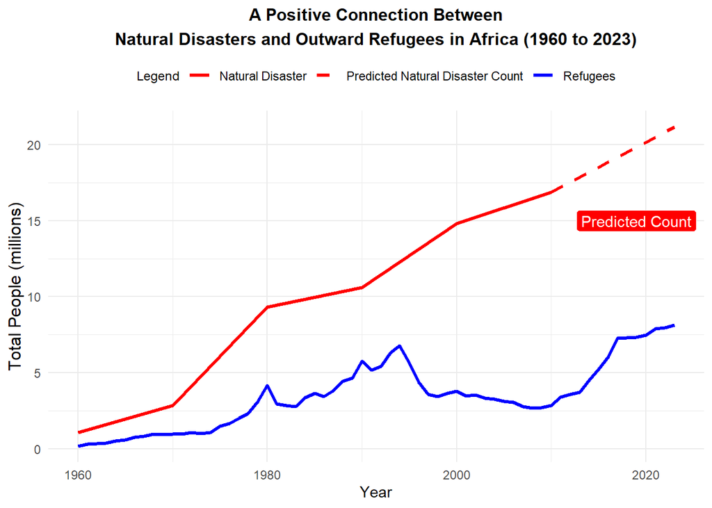

```r
ggplot(Af_all) +
  # Drawing one line for the people affected by natural disaster data
  geom_line(aes(x = Year, y = Dis_Total_Rounded, color = "Natural Disaster"), size = 1.1) +
  # One for the refugee data
  geom_line(aes(x = Year.1,
                y = Refugees_Rounded,
                color = "Refugees"),
            size = 1.1) +
  # And another for the natural disaster projection
  geom_segment(aes(x = 2010,
                   y = 16.8652,
                   xend = 2023,
                   yend = 21.1799,
                   color = "Predicted Natural Disaster Count"),
               linetype = "dashed",
               size = 1.1) +
  scale_y_continuous(name = "Total People (millions)") +
  labs(x = "Year",
       title = "A Positive Connection Between\nNatural Disasters and Outward Refugees in Africa (1960 to 2023)") +
  theme_minimal() +
  scale_color_manual(
    name = "Legend",
    values = c("Natural Disaster" = "red", "Refugees" = "blue", "Predicted Natural Disaster Count" = "red")
  ) +
  geom_label(
    label = "Predicted Count",
    x = 2019,
    y = 15,
    label.size = 0.35,
    color = "white",
    fill="#ff0000"
  ) +
  theme(
    axis.title.y.left = element_text(size = 12),
    plot.title = element_text(size = 12, face = "bold", hjust = 0.5, lineheight = 1.2), # Bold title
    plot.title.position = "panel",
    legend.position = "top",  # Keeps legend at the top
    legend.title = element_text(size = 9),
  )
```

A probable link has already been established between natural disasters and migration (Mbaye & Okara, 2023). The graph suggests Africa has indeed experienced a rise in the number of people affected by natural disasters and the outflow of refugees under UNHCR protection since 1960. Therefore, as more people are affected by natural disasters, the likelihood of migration may increase.

Despite the former not having concrete figures from 2010 onwards, we can safely assume that the number will continue to rise (CRED, 2019).

## II. A Continent Under Scrutiny

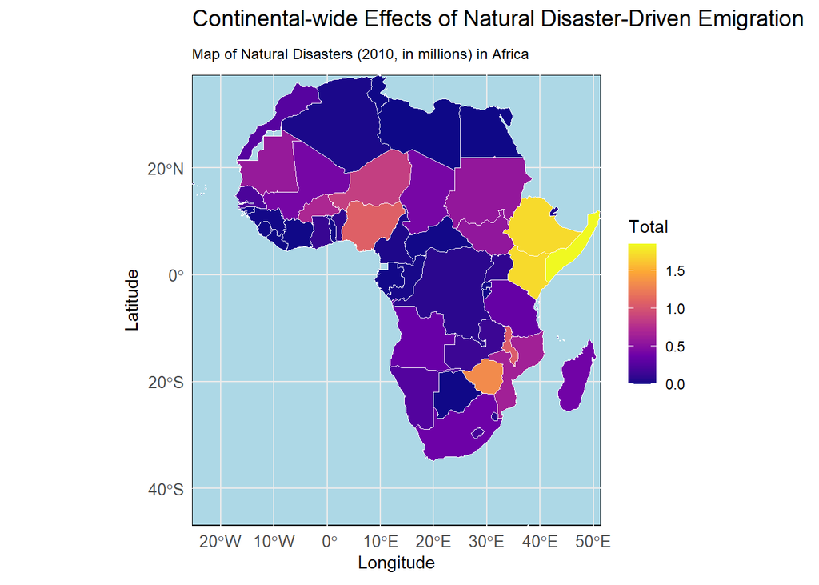

```r
# Load Africa shapefile
africa_map <- ne_countries(scale = "medium", continent = "Africa", returnclass = "sf")

# Then, prepare the data for refugees
df_refugees <- Af_c %>%
  filter(Year == 2010) %>%
  select(Country, X2011_Refugees_Rounded) %>%
  mutate(Map_State = "Refugees (2011, in 300,000s)", Value = X2011_Refugees_Rounded)# Step 1: Prepare the data for both variables (Disasters and Refugees)
# Prepare the data for disasters
df_disasters <- Af_c %>%
  filter(Year == 2010) %>%
  select(Country, Dis_Total_Rounded) %>%
  mutate(Map_State = "Natural Disasters (2010, in millions)", Value = Dis_Total_Rounded)



df_combined <- bind_rows(df_disasters, df_refugees)

# Join the combined data to the map using the country names
africa_map <- africa_map %>%
  left_join(df_combined, by = c("name_ciawf" = "Country"))

# Creating the actual graph with colors
af_viz = ggplot(africa_map) +
  geom_sf(aes(fill = Value), color = "white") +  # Color countries by Value (disasters or refugees)
  scale_fill_viridis_c(option = "C", na.value = "grey80", name = "Total") +  # Color scale
  theme_minimal() +
  labs(subtitle = "Map of {closest_state} in Africa",
       title = "Continental-wide Effects of Natural Disaster-Driven Emigration",
       fill = "Total", x = "Longitude", y = "Latitude") +
  coord_sf(expand = F) +
  theme(
    plot.title = element_text(size = 14, face = "bold"),
    plot.subtitle = element_text(size = 9),
    axis.text = element_text(size = 10),
    panel.background = element_rect(fill = "lightblue")
  )

# Animating the graph
af_anim <- af_viz +
  transition_states(Map_State, transition_length = 2, state_length = 1) +
  enter_fade() + exit_fade()

af_anim
```

This is an opportunity for the Barça Foundation to leverage the global influence of the club for social good and fulfill their 2030 Sustainable Development Agenda.

## III. Rise Of A New African Generation

Coincidentally, Africa’s a gold mine of rising football stars thanks to its growing academies, initiatives, and overseas collaborations (Rietiker-Wright, 2023). In the 2023/2024 season, over 50% of non-European under-22s in Big Five European leagues (minimum 800 minutes played) are African.

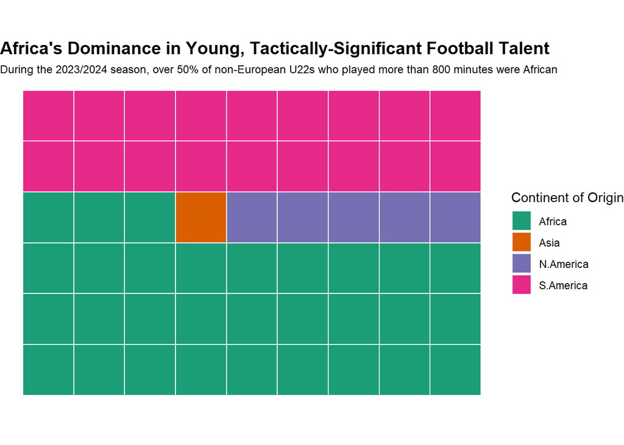

```r
waf = ggplot(y_fb_noneu, aes(fill = Continent, values = Player.Count)) +
  geom_waffle(n_rows = 9, size = 0.5, color = "white",flip = T) +
  labs(title = "Africa's Dominance in Young, Tactically-Significant Football Talent",
       subtitle = "During the 2023/2024 season, over 50% of non-European U22s who played more than 800 minutes were African",
       fill = "Continent of Origin") +
  scale_fill_brewer(palette = "Dark2",
                    labels = c("Africa","Asia","N.America","S.America"))+
  coord_equal() +
  theme_void() +
  theme(
    plot.title = element_text(size = 14, face = "bold"),
    plot.subtitle = element_text(size = 9)
  )

waf
```

Additionally, the naturalization of African refugees is common, leading immigration hubs such as France and Spain to recruit talented individuals to play for their national teams (Onwumechili, 2018).

Exploring the African football scene will massively benefit **both** the Barça Foundation and its parent club.

## IV. Hypothesis Testing

To test whether Africans so-called “dominate” the European football’s youth scene, a proportion test was conducted.

- *p*-value = 3.245 * 10<sup>-11</sup> (or 0.0000000000325)
- *p*-value < 0.05 (a.k.a ⍺-value or significance value)

The key figure is the p-value, which falls significantly lower than the threshold of 0.05. This supports the idea that young African footballers indeed have a larger presence compared to their non-European counterparts.

## V. Limitations

Since the report may contain limitations, Mrs. Segú should exercise caution when making strategic decisions based on its findings.

Nonetheless, the foundation should heavily consider boosting the relief support in Africa as many refugees can still benefit from their work.

# Appendix: Defense of Approach

## I. Client Choice

The Barça Foundation is the only example of a well-managed philanthropical branch of a sports club. Due to an economic downturn, however, the foundation needs a novel idea to expand globally.

Biases may exist due to Spain’s immigration laws.

## II. Statistical Analysis

**Data Cleaning**

Used Python since R’s cleaning is limited.

```python
# DATA CLEANING FOR THE AFRICAN REFUGEES AND NATURAL DISASTER DATA

import pandas as pd
import numpy as np

nd_df = pd.read_csv("G:/YEAR 1/SEMESTER 1/DATA1001/Coding Stuff/Project 2/Big Databases/natural-disasters.csv")
unhcr_reg_df = pd.read_csv("G:/YEAR 1/SEMESTER 1/DATA1001/Coding Stuff/Project 2/Big Databases/unhcr_refg_from.csv")

# Renaming columns
nd_list = ["Dr","Eq",'Dis','V','Fl','Mm','Sto','Ls','Fog','Wf','ExT','GLO']
cats = ['Ded','Inj','Aff','Hom','Total','Recon','InsdDmg','TotEconDmg','Ded%','Inj%','Aff/100k','Hom%','Tot/100k']
len(nd_list)*len(cats)

# General data cleaning
nd_columns = ['Country','Year'] + [f"{nd}_{cat}" for nd in nd_list for cat in cats] + [f"{nd}_TotEcoGDP" for nd in ['Dis','Dr','Eq','ExT','Fl','Ls','Mm','Sto','V']]
nd_df.columns.values[0:167] = nd_columns
nd_df.drop(columns=nd_df.columns[167:],inplace=True)
nd_df.dropna(axis=1,how="all",inplace=True)
nd_df.drop_duplicates(subset=["Country","Year"],inplace=True)

# Selecing data only from Africa (the continent)
af_nd_df = nd_df[(nd_df["Country"] == "Africa") & (nd_df["Year"]>=1960)][['Country','Year','Dis_Aff','Dis_Ded','Dis_Inj','Dis_Hom','Dis_Total','Dis_Recon','Dis_InsdDmg','Dis_TotEconDmg','Dis_Ded%','Dis_Inj%','Dis_Aff/100k']]
# Merging the 2 databases and creating 2 new columns as data rounded (for convenience's sake)
merged_af = pd.concat([af_nd_df.reset_index(),af_unhcr_reg_yearly],axis=1)
merged_af.drop(columns="index",inplace=True)
merged_af["Dis_Total_Rounded"] = merged_af["Dis_Total"].apply(lambda x: round(x/1000000,4))
merged_af["Refugees_Rounded"] = merged_af["Refugees"].apply(lambda x: round(x/1000000,4))

# Renaming the African countries to properly graph the map
african_countries = [
    "Algeria", "Angola", "Benin", "Botswana", "Burkina Faso", "Burundi",
    "Cape Verde", "Cameroon", "Central African Republic", "Chad", "Comoros",
    'Congo, Dem. Rep.','Democratic Republic of Congo','Congo, Rep.',"Congo", "Djibouti",
    "Egypt", "Equatorial Guinea", "Eritrea", "Eswatini", "Ethiopia",
    "Gabon", "Gambia", "Ghana", "Guinea", "Guinea-Bissau", "Cote d'Ivoire",
    "Kenya", "Lesotho", "Liberia", "Libya", "Madagascar", "Malawi", "Mali",
    "Mauritania", "Mauritius", "Morocco", "Mozambique", "Namibia", "Niger",
    "Nigeria", "Rwanda", "Sao Tome and Principe", "Senegal", "Seychelles",
    "Sierra Leone", "Somalia", "South Africa", "South Sudan", "Sudan", "Tanzania",
    "Togo", "Tunisia", "Uganda", "Zambia", "Zimbabwe"
]

# A function to convert the data in the refugees database
def big_num_converter(num):
    if str(num)[-1] == "M":
        return float(num.replace("M",""))*1000000
    elif str(num)[-1] == "k":
        return float(num.replace("k",""))*1000
    else:
        return float(num)

for col in unhcr_reg_df.columns[1:]:
    unhcr_reg_df[col] = unhcr_reg_df[col].apply(big_num_converter)

unhcr_reg_df = unhcr_reg_df.dropna(axis=1,how="all")

# Creaing the 2011 refugees data columnn
af_c_unhcr_reg_df = unhcr_reg_df[unhcr_reg_df["country"].isin(african_countries)]
af_c_unhcr_reg_df = af_c_unhcr_reg_df[af_c_unhcr_reg_df.columns[0:62:61]].fillna(0)
af_c_unhcr_reg_df.columns = ["Country","2011 Refugees"]

af_c_nd_df = nd_df[nd_df["Country"].isin(african_countries)][['Country','Year','Dis_Aff','Dis_Ded','Dis_Inj','Dis_Hom','Dis_Total','Dis_Recon','Dis_InsdDmg','Dis_TotEconDmg','Dis_Ded%','Dis_Inj%','Dis_Aff/100k']]
af_c = af_c_nd_df.merge(af_c_unhcr_reg_df,left_on=["Country"],right_on=["Country"],how="left")
af_c["Dis_Total_Rounded"] = af_c["Dis_Total"].apply(lambda x: round(x/1000000,4))
af_c["2011_Refugees_Rounded"] = af_c["2011 Refugees"].apply(lambda x: round(x/300000,4))
# Dictionary mapping current country names to CIAWF names
ciawf_names = {
    "Cape Verde": "Cabo Verde",
    "Congo, Dem. Rep.": "Congo, Democratic Republic of the",
    "Democratic Republic of Congo": "Congo, Democratic Republic of the",
    "Congo, Rep.": "Congo, Republic of the",
    "Congo": "Congo, Republic of the",
    "Eswatini": "eSwatini",
    "Gambia": "Gambia, The",
    "Cote d'Ivoire": "Cote D'ivoire",
    "Sao Tome and Principe": "São Tomé and Principe",
}
# Apply the mapping to the Country column
af_c['Country'] = af_c['Country'].map(ciawf_names)


merged_af.to_csv("merged_af_exp.csv", index=False)
af_unhcr_reg_yearly.to_csv("af_unhcr_reg_yearly.csv", index=False)

af_c.to_csv("af_c_new.csv", index=False)
```

```python
# DATA CLEANING FOR THE FOOTBALLERS' DATABASE

from bs4 import BeautifulSoup
import requests
import pandas as pd
from functools import reduce

# A function to extract data from FBRef
def get_data(data_url):
    data_url = str(data_url)
    data_page = requests.get(data_url)
    data_soup = BeautifulSoup(data_page.text, "html")

    data_table = data_soup.find("table", class_="min_width sortable stats_table min_width shade_zero")
    data_unfilt_cols = data_table.find_all("th")

    front,back = 0,0
    for index, header in enumerate(data_unfilt_cols):
        if header.get_text() == "Player":
            front = index
        if header.get_text() == "Matches":
            back = index + 1
        if front and back:
            break

    data_cols = [title.text.strip() for title in data_unfilt_cols][front:back]
    data_df = pd.DataFrame(columns=data_cols)

    data_col_data_draft = data_table.find_all("tr")
    data_col_data = []
    i = 2
    while i < len(data_col_data_draft):
        data_col_data.extend(data_col_data_draft[i:i+25])
        i += 25 + 1
    for data_row in data_col_data:
        data_unfil_row = data_row.find_all("td")
        data_rows = [title.text.strip() for title in data_unfil_row]
        data_length = len(data_df)
        data_df.loc[data_length] = data_rows

    data_numeric_cols = data_df.columns[5:len(data_df.columns)-1]
    for col in data_numeric_cols:
        if col == "Born":
            data_df[col] = pd.to_datetime(data_df[col],format="%Y").dt.year
        else:
            data_df[col] = data_df[col].apply(pd.to_numeric)
            data_df[col] = data_df[col].fillna(0)

    data_df.drop(columns="Matches", inplace=True)

    data_df["Nation"] = data_df["Nation"].apply(lambda nation: nation.split()[1] if isinstance(nation, str) and len(nation.split()) > 0 else None)
    data_df["Comp"] = data_df["Comp"].apply(lambda comp: " ".join(comp.split()[1:]) if isinstance(comp, str) and len(comp.split()) > 0 else None)

    data_df.reset_index(drop=True, inplace=True)

    return data_df

def_df = get_data("https://fbref.com/en/comps/Big5/2023-2024/defense/players/2023-2024-Big-5-European-Leagues-Stats")
# Renaming the columns
def_df.columns = ["Player", "Nation", "Pos", "Squad",'Comp', "Age", "Born", "90s",
                  "D_Tkl", "D_TklW", "Tkl_Def 3rd", "Tkl_Mid 3rd", "Tkl_Att 3rd",
                  "Chal_Tkl", "Chal_Att", "Chal_Tkl%", "Chal_Lost",
                  "Blocks", "B_Sh", "B_Pass", "Int", "Tkl+Int", "Clr", "Err"]

df_final = get_data("https://fbref.com/en/comps/Big5/2023-2024/gca/players/2023-2024-Big-5-European-Leagues-Stats")
# Filtering
non_eu_youngsters = df_final[(~df_final["Nation"].isin(EU)) & (df_final["Age"]<22) & (df_final["90s"]*90>800)]
# COunting the number of satisfactory players per continent and create a dataframe from that
continent_counts = {
    'AF': non_eu_youngsters[non_eu_youngsters["Nation"].isin(AF)].shape[0],
    'AS': non_eu_youngsters[non_eu_youngsters["Nation"].isin(AS)].shape[0],
    'N_A': non_eu_youngsters[non_eu_youngsters["Nation"].isin(N_A)].shape[0],
    'OC': non_eu_youngsters[non_eu_youngsters["Nation"].isin(OC)].shape[0],
    'SA': non_eu_youngsters[non_eu_youngsters["Nation"].isin(SA)].shape[0]
}
continent_counts_df = pd.DataFrame(list(continent_counts.items()), columns=['Continent', 'Player Count'])

continent_counts_df.to_csv("continent_counts_df.csv")
```

**Hypothesis Testing**

### 1. Hypotheses

Theoretically, the proportion of young players from Africa matches other continents’ (20%).

*H<sub>0</sub>:* **20%** of impactful, non-European youngsters in Europe’s Big Five are African.

*H<sub>1</sub>:* **More than 20%** of impactful, non-European youngsters in Europe’s Big Five are African.

### 2. Assumptions

- **Database Accuracy:** All footballers’ statistics are correct.
- **Independence:** Players’ inclusion should be independent of others.

### 3. Test Statistics & p-values

```r
Af_count = y_fb_noneu %>% filter(Continent == "AF") %>% pull(Player.Count)
All_count = y_fb_noneu %>% pull(Player.Count) %>% sum()


ts = ((Af_count) - 0.2*All_count)/sqrt(All_count*0.2*(1-0.2))
sprintf("Test statistic: %f",ts)
```

```
[1] "Test statistic: 6.531973"
```

```r
prop.test(Af_count,All_count,0.2, alt = "greater", correct = F)
```

```
    1-sample proportions test without continuity correction

data:  Af_count out of All_count, null probability 0.2
X-squared = 42.667, df = 1, p-value = 3.245e-11
alternative hypothesis: true p is greater than 0.2
95 percent confidence interval:
 0.4443332 1.0000000
sample estimates:
        p
0.5555556
```

### 4. Conclusion: Reject *H<sub>0</sub>*

**Linear Modelling**

Linear modeling provides a predictive equation for estimating people affected by natural disasters.

```r
ND_lm = lm(Dis_Total_Rounded ~ Year, data = Af_all)
ND_lm
```

```
Call:
lm(formula = Dis_Total_Rounded ~ Year, data = Af_all)

Coefficients:
(Intercept)         Year
  -649.6215       0.3319
```

$$y = 0.3319x - 649.6215$$

```r
cor(Af_all$Dis_Total_Rounded,Af_all$Refugees_Rounded, use = "complete.obs")
```

```
[1] 0.9401918
```

**Player Selection Criteria**

- “U22s”: Reflects Barcelona’s youth visions.
- “Big Five Leagues”: Measures worldwide reputation.
- “Non-European”: Over-representation (Europeans) exclusion.
- “Minimum 800 Minutes Played”: Measures impact.

These criteria filter young, tactically-influential, non-European from elite European clubs.

## III. Limitations

- Natural disasters’ data is sparse (1 datapoint/10 years).
- The Natural Disaster database only covers up to 2010.
- Some countries/territories cannot provide data.

# Ethics Statement

### Shared Professional Values: Respect

- The data used to produce this project excluded countries or players who are unable to provide data to respect their privacy, avoiding potential breach of privacy policy.

### Maintaining Confidence in Statistics

- Provided concrete figures, realistic hypotheses, and listed possible limitations of the analysis to properly and truthfully inform the readers of the research result.
- Cleaned data to exclude the outliers or irrelevant values, unify data and improve coherence.
- Acknowledged the limitations.
- Highlighted areas for possible improvements, aiding future research.

# Acknowledgements

| Name | Type of Resource | URL/Source |
| --- | --- | --- |
| Topic 4 & 8 Extensions | Ed Lessons | https://edstem.org/au/courses/16787/lessons/ |
| *Building a nice legend with R and ggplot2* | Blog/Post | https://r-graph-gallery.com/239-custom-layout-legend-ggplot2.html |
| *Create your own discrete scale* | Documentation | https://ggplot2.tidyverse.org/reference/scale_manual.html |
| *Create maps using the sf package in R programming* | Youtube Video | https://www.youtube.com/watch?v=F0ZRYo4SUb8 |
| *Waffle chart (square pie) in ggplot2* | Documentation | https://r-charts.com/part-whole/waffle-chart-ggplot2/ |
| *Amazon Web Scraping Using Python* | Youtube Video | https://www.youtube.com/watch?v=HiOtQMcI5wg |
| Grammarly | Spell/Grammar Checker | https://app.grammarly.com |

# Reference

Centre for Research on the Epidemiology of Disasters (CRED). (2019, November). Disasters in Africa: 20 Year Review (2000-2019*). CRED Crunch, (56), 2. https://drmims.sadc.int/sites/default/files/document/2020-03/2019_SADC_CRED_USAID_UCLouvain_Disasters_Africa_20yearreview.pdf

International Organization for Migration (IOM). (2011, July 18). Drought Related Migration on the Increase in the Horn of Africa. https://www.iom.int/news/drought-related-migration-increase-horn-africa

Onwumechili, C. (2018, July 20). African countries are losing out on their football talent. They need to figure out why. The Conversation. Retrieved October 9, 2024, from https://theconversation.com/african-countries-are-losing-out-on-their-football-talent-they-need-to-figure-out-why-100039

Rietiker, J. (2023, November 2). Football’s Next Generation: The African Talent Factory | by Jamie Rietiker-Wright. Medium. https://medium.com/@jamie72155/footballs-next-generation-the-african-talent-factory-1549316aecaa

Mbaye, L., Okara, A. Climate change, natural disasters, and migration. IZA World of Labor 2023: 346 doi: 10.15185/izawol.346.v2